# predmachlearn-006-project

Knut Behrends, October 2014

### Qualitative Activity Recognition of Weight Lifting Exercises.

A Programming Project for Coursera MOOC “Practical Machine learning”, v006

### Synopsis

> Predicting the quality of physical exercising by means of automated “Human Activity Recognition”. This means analysis of sensor data acquired from 6 men doing biceps-curls with dumbbells. The sensor data can be used to tell *how correct* the movements of the workout were done.  
> Please read Background to get familiar with the assignment and the subject matter. You can also read an [academic paper](http://groupware.les.inf.puc-rio.br/public/papers/2013.Velloso.QAR-WLE.pdf) from 2013 on the open dataset and its use in sports medicine.

> The [researchers](http://groupware.les.inf.puc-rio.br/work.jsf?p1=11201) were a team of at least of five people. Certainly they had the time to analyse the dataset very thoroughly. In contrast, I am a single individual taking off a couple of evenings to take a peek into the dataset. So this analysis is briefer. I will not take time-slices, as the authors did. It will focus on the dataset of a whole, and “only” on 50 of the 160 attributes provided.

> For performance reasons, I used machine-learning toolbox *RWeka* (not *caret*) to run a tree-based algorithm *(J48)* on the 19600-row training data. The goal was to predict unknown values of the classification-attribute of a testing dataset with 20-rows.

### Exploratory Analysis 1: Basics

#### Read In Data Files, Load R Packages

```r
training <- read.csv("../data/pml-training.csv")
testing <- read.csv("../data/pml-testing.csv")
```

```r
library(Hmisc)
library(ggplot2)
library(caret) # for featurePlot
library(RWeka) # for predicting
#contents(training)
#descr <- describe(training)
#str(descr)
```

The dataset is pretty clean. There is not much preprocessing necessary. All columns have nice all-lowercase, self-describing names, and few datatypes : integer, factor, numeric). There are 160 variables:

```r
nas <- colSums(is.na(training));table(nas)
```

```
## nas
##     0 19216
##    93    67
```

There are 93 columns which have 0 NA values, and 67 columns all of which have the same number of 19216 NAs.

The 6 participants have performed the same number of exercises, at least it is comparable at the same order of magnitude.

```r
table(training$user_name)
```

```
##
##   adelmo carlitos  charles   eurico   jeremy    pedro
##     3892     3112     3536     3070     3402     2610
```

They have also produced the same number of *types* of exercises, (which happens to be the classification attribute, labeled “classe” by the researchers):

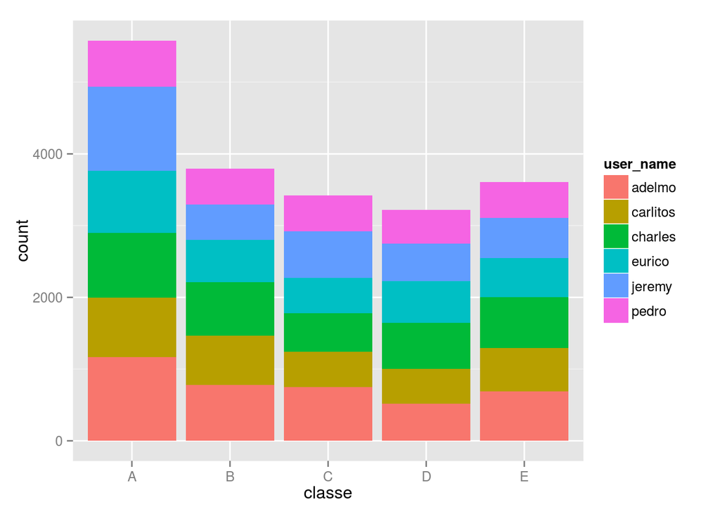

```r
qplot(classe, data=training, fill=user_name)
```

Further exploratory analysis indicates that there are no outliers, at least not among in the most interesting parameters, to be described below in section “Exploratory Analyis 3”.

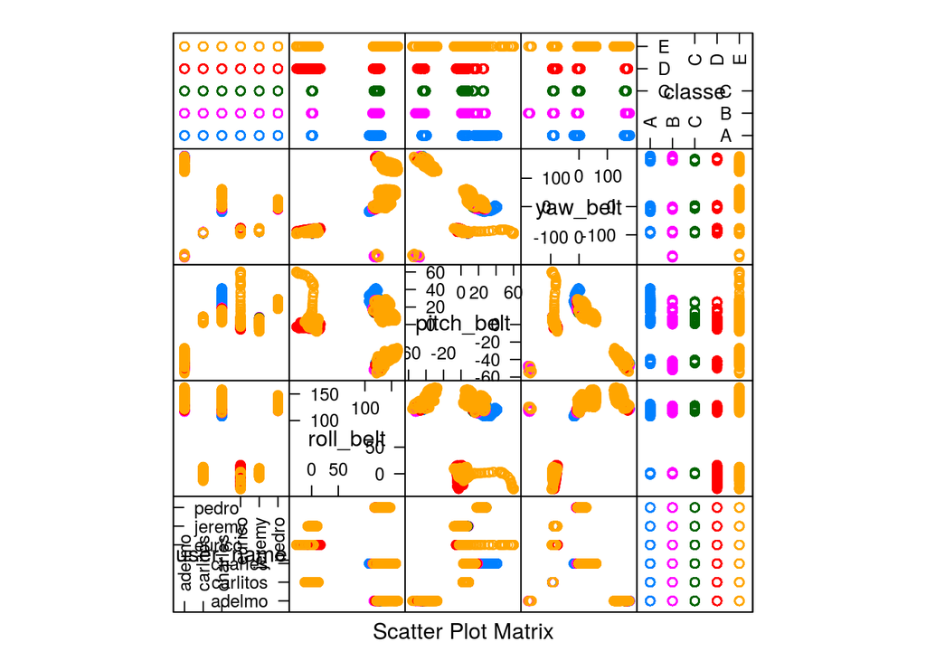

```r
#cols = "^roll|^pitch|^yaw|user_name|classe"
cols = "(?:^roll|^pitch|^yaw)_belt"
cols <- paste0(cols, "|user_name|classe")
#sample(nrow(training), nsamp) &
training_sample <-training[,grep(cols, names(training), perl=TRUE)]
featurePlot(x=training_sample, y=training_sample$classe, plot="pairs")
```

For example, 3 users “rolled their belt”, i.e. *leaned forward* to some degree, and 3 didn’t.

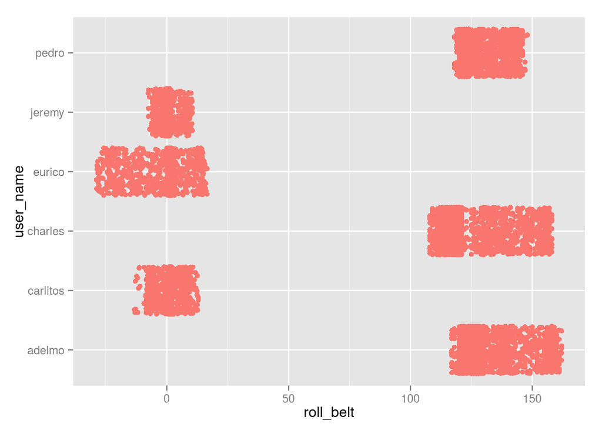

This corresponds to the second-from-left plot in the last row of the plotmatrix.  
I have performed more plotting, but this is omitted here.

### Exploratory Analysis 2: Temporarily append testing data to training data.

In machine learning, it is important to make training data and testing data set *exactly* compatible. Here, training dataset and testing dataset differ in number of columns (1 column), and some colums differ in datatypes (logicals vs factors). I’ll temporarily append the tiny testing dataset (n=20) to the training data (n ~ 19600) to do the subsequent attribute filtering only once.

```r
#remove last column, "problemID"
t2 <- testing[,1:(ncol(testing)-1)]
#add empty "classe" col
t2[ , "classe"] <- NA
#convert to factor
t2$classe <- factor((t2$classe))
class(t2$classe)
```

```
## [1] "factor"
```

Check if training data and testing data have different column names:

```r
comp1 <- names(t2) != names(training)
neqcol <- length(which(as.logical(comp1), arr.ind = TRUE))
```

There are 0 non-equal column names in testing and training data set.

Check if training data and testing data have different column *types*:

```r
comp2 <- unlist(lapply(t2, class)) != unlist(lapply( training, class))
comp2factinds <-which(as.logical(comp2))
```

```r
#convert logicals to  factors
t2[sapply(t2, is.logical)] <- lapply(t2[sapply(t2, is.logical)], as.factor)

# another round of checks
temp1 <- lapply(comp2factinds, FUN<- function(x){t2[,x] <- factor(t2[,x])})
temp2 <- unlist(lapply(t2, class))
temp3 <- unlist(lapply( training, class))

comp3 <- unlist(temp2 != temp3)
comp3factinds <-which(as.logical(comp3))

ntraining_before <- nrow(training)
training <- rbind(training, t2)
ntraining_after <-  nrow(training)
rm(t2)
```

The training data set has grown from 19622 to 19642 rows. I’ll split them apart again, after subsetting.

### Exploratory Analysis 3: Selecting variables for modeling

Close inspection of the attributes indicates that there are some more primary (“raw”) sensor data,and there are lots of derived attributes, such as projections of raw coordinates into some spatial planes (the x-y plane, the x-z-plane etc). There are also descriptive statistics calculated from the raw sensor data. These descriptive statistics are prefixed (or suffixed) with “total_”, “var_”, “curtosis_”, “skewness_”, etc.

I do not know how they calculated these decriptive metrics. Probably by time-slicing (folding) some of the raw data. Note there are some columns *(new_window, num_window)*, maybe indicative of sliding time-windows.

There are some time-series data encoded in the dataset *(raw_timestamp_part_1, raw_timestamp_part_2, cvtd_timestamp)*, but we’ll just ignore them. They were important for the researchers, to conduct various numerical experiments: how fast did their algorithms and models respond? How small can the training dataset be to make accurate predictions?

All these variables by definition represent *interactions* between the raw data. These derived attributes also contain lots of NAs. To make modeling easier, it is best to *remove* the attributes entirely.

#### Removing irrelevant attributes

In the assignment’s synopsis it says, the sensors were placed on *belt, forearm, arm*, and *dumbbell*. The sensors register

1. *x-y-z* coordinates (or accelerations) which are integers.
2. *roll, pitch* and *yaw* which are angle measurements, which are floats.

There are also some categorical variables, *user_name*, and *classe* which we must keep for obvious reasons.

Let’s filter out the relevant variables from the dataset, by building a complex regular expression for matching relevant column names:

```r
rx <- "(^roll|^pitch|^yaw|classe|user_name|.*_x$|.*_y$|.*_z$).*"
cols <-grep(rx, names(training), perl=TRUE, value=TRUE)
```

Subsetting the data frame:

```r
training <- subset(training, select=cols)
```

**The interesting remaining columns are**:

```r
contents(training)
```

```
##
## Data frame:training  19642 observations and 50 variables    Maximum # NAs:20
##
##                   Levels Storage NAs
## user_name              6 integer   0
## roll_belt                 double   0
## pitch_belt                double   0
## yaw_belt                  double   0
## gyros_belt_x              double   0
## gyros_belt_y              double   0
## gyros_belt_z              double   0
## accel_belt_x             integer   0
## accel_belt_y             integer   0
## accel_belt_z             integer   0
## magnet_belt_x            integer   0
## magnet_belt_y            integer   0
## magnet_belt_z            integer   0
## roll_arm                  double   0
## pitch_arm                 double   0
## yaw_arm                   double   0
## gyros_arm_x               double   0
## gyros_arm_y               double   0
## gyros_arm_z               double   0
## accel_arm_x              integer   0
## accel_arm_y              integer   0
## accel_arm_z              integer   0
## magnet_arm_x             integer   0
## magnet_arm_y             integer   0
## magnet_arm_z             integer   0
## roll_dumbbell             double   0
## pitch_dumbbell            double   0
## yaw_dumbbell              double   0
## gyros_dumbbell_x          double   0
## gyros_dumbbell_y          double   0
## gyros_dumbbell_z          double   0
## accel_dumbbell_x         integer   0
## accel_dumbbell_y         integer   0
## accel_dumbbell_z         integer   0
## magnet_dumbbell_x        integer   0
## magnet_dumbbell_y        integer   0
## magnet_dumbbell_z         double   0
## roll_forearm              double   0
## pitch_forearm             double   0
## yaw_forearm               double   0
## gyros_forearm_x           double   0
## gyros_forearm_y           double   0
## gyros_forearm_z           double   0
## accel_forearm_x          integer   0
## accel_forearm_y          integer   0
## accel_forearm_z          integer   0
## magnet_forearm_x         integer   0
## magnet_forearm_y          double   0
## magnet_forearm_z          double   0
## classe                 5 integer  20
##
## +---------+-------------------------------------------+
## |Variable |Levels                                     |
## +---------+-------------------------------------------+
## |user_name|adelmo,carlitos,charles,eurico,jeremy,pedro|
## +---------+-------------------------------------------+
## |classe   |A,B,C,D,E                                  |
## +---------+-------------------------------------------+
```

These 50 attributes will be used for building a machine learning model.  
Note that there are only 20 NAs in the “classe” attribute. These are the appended test cases.

However, a feature plot (plotmatrix) for *all* 50 attributes and *all* 19642 rows takes a few minutes to build.  
This is unacceptably slow. So instead of using *caret* in RStudio, I prefer to work in the Weka GUI, which plots data much faster.

### Building a machine learning model.

After some experimenting, I used a *J48* tree based algorithm.  
*J48* generates unpruned or pruned C4.5 decision trees (Quinlan, 1993).

```r
library(RWeka)
testdata <- tail(training,20)
#try(write.arff(testdata, "testing-transformed-50attrs.arff", eol = "\n"))
traindata <- training[-20,]
#try(write.arff(traindata, "training-transformed-50attrs.arff", eol = "\n"))
m1 <- J48(classe ~ ., data = traindata)

#J48(formula, data, subset, na.action,
#    control = Weka_control(), options = NULL)
```

#### Summary of the J48 model.

```r
summary(m1)
```

```
##
## === Summary ===
##
## Correctly Classified Instances       19518               99.4751 %
## Incorrectly Classified Instances       103                0.5249 %
## Kappa statistic                          0.9934
## Mean absolute error                      0.0038
## Root mean squared error                  0.0433
## Relative absolute error                  1.1874 %
## Root relative squared error             10.8968 %
## Coverage of cases (0.95 level)          99.7044 %
## Mean rel. region size (0.95 level)      20.3099 %
## Total Number of Instances            19621
##
## === Confusion Matrix ===
##
##     a    b    c    d    e   <-- classified as
##  5568    4    2    2    3 |    a = A
##    10 3776    6    3    2 |    b = B
##     2   13 3394    8    5 |    c = C
##     3    6   15 3186    6 |    d = D
##     2    4    3    4 3594 |    e = E
```

The model accuracy is 99.48% - not bad for a first run.

The predictions for the 20 test cases are:

```r
pred1 <- predict(m1, newdata=testdata); tail(pred1, 20)
```

```
##  [1] A A B A A E D B A A B C B A E E A B B B
## Levels: A B C D E
```

I submitted this to the Coursera grader, and got 17 of 20 of the 20 test cases right.

### ‘Bagging’ machine learning model.

Then I used a *Bagging* algorithm (Breiman, 1996).

```r
library(RWeka)
m2 <- Bagging(classe ~ ., data = training[-20,])

#J48(formula, data, subset, na.action,
#    control = Weka_control(), options = NULL)
```

```r
summary(m2)
```

```
##
## === Summary ===
##
## Correctly Classified Instances       19511               99.4394 %
## Incorrectly Classified Instances       110                0.5606 %
## Kappa statistic                          0.9929
## Mean absolute error                      0.0169
## Root mean squared error                  0.0588
## Relative absolute error                  5.3291 %
## Root relative squared error             14.784  %
## Coverage of cases (0.95 level)          99.9898 %
## Mean rel. region size (0.95 level)      24.4279 %
## Total Number of Instances            19621
##
## === Confusion Matrix ===
##
##     a    b    c    d    e   <-- classified as
##  5567   10    1    0    1 |    a = A
##    14 3770    8    2    3 |    b = B
##     4   10 3386   22    0 |    c = C
##     1    6   17 3189    3 |    d = D
##     0    4    0    4 3599 |    e = E
```

The model accuracy is 99.44% - also not bad.

The predictions for the 20 test cases are slightly different this time:

```r
pred2 <- predict(m2, newdata=testdata); tail(pred2, 20)
```

```
##  [1] B A B A A E D B A A B C B A E E A B B B
## Levels: A B C D E
```

Only element 1, “B”, is different. I submitted this to the Coursera grader, and got it right.

I checked a bunch of other algorithms, e.g. “Logisitic, SMO, NaiveBayes*, all with default options, but none performed better.

### References

L. Breiman (1996). Bagging predictors. Machine Learning, 24/2, 123–140.

### Appendix

The following is irrelevant to the readers. However

1. it was necessary for completion of the assignment.
2. it documents some intermediate steps.

#### Export to file, for Weka (Explorer GUI) to import

```
getwd()
library(RWeka)
# write composite dataset to arff file
write.arff(t2, "testing-transformed.arff", eol = "\n")
```

#### *… Perform analysis in the Weka GUI …*

```
(This is not reprocuded here.)
```

#### Get predictions from arff file written by weka

```
try(system("ls -l *.arff"))
predicts <- read.arff("trainingtesting-cols-predictions.arff")
res <- as.vector(t(tail(predicts[3],20) ))
write.arff(t2, "testing-transformed.arff", eol = "\n")
```

#### Export to file system, for submission to Coursera.

Write one file per prediction, each file consisting only of one prediction, a capital letter , from A to E. We also write 1 file with all predictions for ’diff’ing experiments.

```
try(system("mkdir results"))
setwd("results")
pml_write_files(res)

pml_write_files = function(x){
  n = length(x)
  for(i in 1:n){
    filename = paste0("problem_id_",i,".txt")
    write.table(x[i],file=filename,quote=FALSE,row.names=FALSE,col.names=FALSE)
  }
 x <- 1:20
  l <- c()
  n <- 20
  for(i in 1:n){
        l <- paste0(l, paste0(i, "\t",  x[i], "\n"))

  }
  # write 1 file with all predictions for 'diff'ing
  d <- format(Sys.time(), "%Y%m%d_%H%M")
  filename = paste0("_problems_20_",d,".txt")
  write.table(paste0(d, "\n\n",l),file=filename,quote=FALSE,row.names=FALSE,col.names=FALSE)
  paste0(getwd(), .Platform$file.sep, filename)
}
```